# ME314 Homework 5

```python
    #######################################
    # Putting it all together and plotting.
    figure1=dict(data=data, layout=layout, frames=frames)
    iplot(figure1)

def animate_triple_pend(theta_array, L1=1, L2=1, L3=1, T=10):
    """
    Function to generate web-based animation of triple-pendulum system

    Parameters:
    ================================================
    theta_array:
        trajectory of theta1 and theta2, should be a NumPy array with
        shape of (3,N)
    L1:
        length of the first pendulum
    L2:
        length of the second pendulum
    L3:
        length of the third pendulum
    T:
        length/seconds of animation duration

    Returns: None
    """

    ################################
    # Imports required for animation.
    from plotly.offline import init_notebook_mode, iplot
    from IPython.display import display, HTML
    import plotly.graph_objects as go

    #######################
    # Browser configuration.
    def configure_plotly_browser_state():
        import IPython
        display(IPython.core.display.HTML('''
            <script src="/static/components/requirejs/require.js"></script>
            <script>
              requirejs.config({
                paths: {
                  base: '/static/base',
                  plotly: 'https://cdn.plot.ly/plotly-1.5.1.min.js?noext',
                },
              });
            </script>
            '''))
    configure_plotly_browser_state()
    init_notebook_mode(connected=False)

    ###############################################
    # Getting data from pendulum angle trajectories.
    xx1=L1*np.sin(theta_array[0])
    yy1=-L1*np.cos(theta_array[0])
    xx2=xx1+L2*np.sin(theta_array[0]+theta_array[1])
    yy2=yy1-L2*np.cos(theta_array[0]+theta_array[1])
    xx3=xx2+L3*np.sin(theta_array[0]+theta_array[1]+theta_array[2])
    yy3=yy2-L3*np.cos(theta_array[0]+theta_array[1]+theta_array[2])
    N = len(theta_array[0]) # Need this for specifying length of simulation

    ####################################
    # Using these to specify axis limits.
    xm=np.min(xx1)-0.5
    xM=np.max(xx1)+0.5
    ym=np.min(yy1)-2.5
    yM=np.max(yy1)+1.5

    ###########################
    # Defining data dictionary.
    # Trajectories are here.
    data=[dict(x=xx1, y=yy1,
               mode='lines', name='Arm',
               line=dict(width=2, color='blue')
              ),
          dict(x=xx1, y=yy1,
               mode='lines', name='Mass 1',
               line=dict(width=2, color='purple')
              ),
          dict(x=xx2, y=yy2,
               mode='lines', name='Mass 2',
               line=dict(width=2, color='green')
              ),
          dict(x=xx3, y=yy3,
               mode='lines', name='Mass 3',
               line=dict(width=2, color='yellow')
              ),
          dict(x=xx1, y=yy1,
               mode='markers', name='Pendulum 1 Traj',
               marker=dict(color="purple", size=2)
              ),
          dict(x=xx2, y=yy2,
               mode='markers', name='Pendulum 2 Traj',
               marker=dict(color="green", size=2)
              ),
          dict(x=xx3, y=yy3,
               mode='markers', name='Pendulum 3 Traj',
               marker=dict(color="yellow", size=2)
              ),
        ]

    ################################
    # Preparing simulation layout.
    # Title and axis ranges are here.
    layout=dict(xaxis=dict(range=[xm, xM], autorange=False, zeroline=False,dtick=1),
                yaxis=dict(range=[ym, yM], autorange=False, zeroline=False,scaleanchor = "x",dtick=1),
                title='Triple Pendulum Simulation',
                hovermode='closest',
                updatemenus= [{'type': 'buttons',
                               'buttons': [{'label': 'Play','method': 'animate',
                                            'args': [None, {'frame': {'duration': T, 'redraw': False}}]},
                                           {'args': [[None], {'frame': {'duration': T, 'redraw': False}, 'mode': 'immediate',
                                            'transition': {'duration': 0}}],'label': 'Pause','method': 'animate'}
                                          ]
                              }]
               )

    ########################################
    # Defining the frames of the simulation.
    # This is what draws the lines from
    # joint to joint of the pendulum.
    frames=[dict(data=[dict(x=[0,xx1[k],xx2[k],xx3[k]],
                            y=[0,yy1[k],yy2[k],yy3[k]],
                            mode='lines',
                            line=dict(color='red', width=3)
                            ),
                       go.Scatter(
                            x=[xx1[k]],
                            y=[yy1[k]],
                            mode="markers",
                            marker=dict(color="blue", size=12)),
                       go.Scatter(
                            x=[xx2[k]],
                            y=[yy2[k]],
                            mode="markers",
                            marker=dict(color="blue", size=12)),
                       go.Scatter(
                            x=[xx3[k]],
                            y=[yy3[k]],
                            mode="markers",
                            marker=dict(color="blue", size=12)),
                      ]) for k in range(N)]

    #######################################
    # Putting it all together and plotting.
    figure1=dict(data=data, layout=layout, frames=frames)
    iplot(figure1)
```

```python
def animate_single_pend(theta_array, L=1, T=10):
    """
    Function to generate web-based animation of a single-pendulum system

    Parameters:
    ================================================
    theta_array:
        trajectory of theta, should be a NumPy array with shape (N,)
    L:
        length of the pendulum
    T:
        length/seconds of animation duration

    Returns: None
    """

    ################################
    # Imports required for animation.
    from plotly.offline import init_notebook_mode, iplot
    from IPython.display import display, HTML
    import plotly.graph_objects as go

    #######################
    # Browser configuration.
    def configure_plotly_browser_state():
        import IPython
        display(IPython.core.display.HTML('''
            <script src="/static/components/requirejs/require.js"></script>
            <script>
              requirejs.config({
                paths: {
                  base: '/static/base',
                  plotly: 'https://cdn.plot.ly/plotly-latest.min.js?noext',
                },
              });
            </script>
            '''))
    configure_plotly_browser_state()
    init_notebook_mode(connected=False)

    ###############################################
    # Getting data from pendulum angle trajectory.
    xx = L * np.sin(theta_array)
    yy = -L * np.cos(theta_array)
    N = len(theta_array)  # Length of simulation

    ####################################
    # Using these to specify axis limits.
    xm = np.min(xx) - 0.5
    xM = np.max(xx) + 0.5
    ym = np.min(yy) - 1.5
    yM = np.max(yy) + 0.5

    ###########################
    # Defining data dictionary.
    data = [
        dict(x=xx, y=yy, mode='lines', name='Pendulum Arm', line=dict(width=2, color='blue')),
        dict(x=xx, y=yy, mode='markers', name='Pendulum Mass Traj', marker=dict(color="blue", size=2)),
    ]

    ################################
    # Preparing simulation layout.
    layout = dict(
        xaxis=dict(range=[xm, xM], autorange=False, zeroline=False, dtick=1),
        yaxis=dict(range=[ym, yM], autorange=False, zeroline=False, scaleanchor="x", dtick=1),
        title='Single Pendulum Simulation',
        hovermode='closest',
        updatemenus=[{'type': 'buttons',
                      'buttons': [{'label': 'Play', 'method': 'animate',
                                   'args': [None, {'frame': {'duration': T, 'redraw': False}}]},
                                  {'args': [[None], {'frame': {'duration': T, 'redraw': False},
                                                     'mode': 'immediate', 'transition': {'duration': 0}}],
                                   'label': 'Pause', 'method': 'animate'}]
                      }]
    )

    ########################################
    # Defining the frames of the simulation.
    frames = [dict(data=[dict(x=[0, xx[k]], y=[0, yy[k]], mode='lines', line=dict(color='red', width=3)),
                         go.Scatter(x=[xx[k]], y=[yy[k]], mode="markers", marker=dict(color="blue", size=12)),
                        ]) for k in range(N)]

    #######################################
    # Putting it all together and plotting.
    figure1 = dict(data=data, layout=layout, frames=frames)
    iplot(figure1)
```

```python
from IPython.core.display import HTML
display(HTML("<table><tr><td><img src='https://github.com/MuchenSun/ME314pngs/raw/master/singlepend.JPG' width=350' height='350'></table>"))
```

## Problem 1 (5pts)

**Turn in: A copy of the code used to solve the EL-equations and numerically simulate the system. Also include code output, which should be the plot of the trajectory versus time.**

```python
# Define the variables and parameters
t, g, m, R = sym.symbols(r't, g, m, R')

th = sym.Function(r'\theta')(t)

th_dot = th.diff(t)

x = R*sym.sin(th)
y = -R*sym.cos(th)

x_dot = x.diff(t)
y_dot = y.diff(t)

KE = (m*(x_dot**2 + y_dot**2))/2
PE = m*g*y

lagrangian = KE - PE
lagrangian = sym.simplify(lagrangian)

# Display Lagrangian
print('\033[1mLagrangian of the system: ')
display(lagrangian)
print("\n")

# Wrap the lagrangian into a SymPy Matrix
L = sym.Matrix([lagrangian])
# display(L)

q = sym.Matrix([th])
qdot = q.diff(t)
qddot = qdot.diff(t)

# Compute Jacobian
dLdq = L.jacobian(q)
dLdqdot = L.jacobian(qdot)

# print('\033[1mEuler Lagrangian Equations')
EL = dLdqdot.diff(t) - dLdq

# for exp, n in zip(EL, range(1,3)):
#   print("\033[1mEL Equation {}".format(n))
#   display(sym.Eq(exp, 0))
# print("\n")

# LHS of the EL equations
lhs = sym.Matrix([exp for exp in EL])

# RHS of the EL equations
rhs = sym.Matrix([0 for exp in EL])

# Define the equations
eqns = sym.Eq(lhs, rhs)
print('\033[1mEuler Lagrangian Equations')
display(eqns)

solns = sym.solve(eqns, qddot, dict=True)

for sol in solns:
    print('\n\033[1mSolution: ')
    for q_ in qddot:
        display(sym.simplify(sym.Eq(q_, sol[q_])))
        print("\n")

# Substitute constants into symbolic solutions
subs_dict = {m:1, g:9.8, R:1}

c_sub_solns = [{q_: soln[q_].subs(subs_dict) for soln in solns for q_ in qddot}]

for c_sub_soln in c_sub_solns:
    print('\n\033[1mSolution: ')
    for q_ in qddot:
        display(sym.simplify(sym.Eq(q_, c_sub_soln[q_])))
        print("\n")

# Lamdifying the constant substituted solutions for theta1_ddot and theta2_ddot
state_vec = [th]
lambdified_solns = [sym.lambdify(state_vec, c_sub_soln[q_]) for c_sub_soln in c_sub_solns for q_ in qddot]
thddot_func, = lambdified_solns
```

```
Lagrangian of the system:
```

$\displaystyle \frac{R m \left(R \left(\frac{d}{d t} \theta{\left(t \right)}\right)^{2} + 2 g \cos{\left(\theta{\left(t \right)} \right)}\right)}{2}$

```
Euler Lagrangian Equations
```

$\displaystyle \left[\begin{matrix}R^{2} m \frac{d^{2}}{d t^{2}} \theta{\left(t \right)} + R g m \sin{\left(\theta{\left(t \right)} \right)}\end{matrix}\right] = \left[\begin{matrix}0\end{matrix}\right]$

```
Solution:
```

$\displaystyle \frac{d^{2}}{d t^{2}} \theta{\left(t \right)} = - \frac{g \sin{\left(\theta{\left(t \right)} \right)}}{R}$

```
Solution:
```

$\displaystyle \frac{d^{2}}{d t^{2}} \theta{\left(t \right)} = - 9.8 \sin{\left(\theta{\left(t \right)} \right)}$

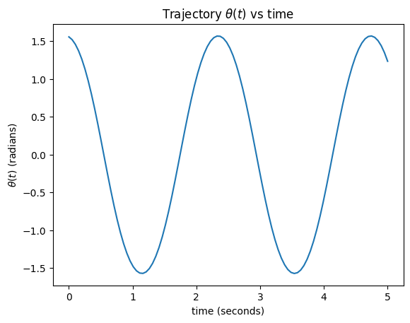

```python
# define extended dynamics for the pendulum
def pendulum_dyn(x):
  """
    System dynamics function (extended)

    Parameters
    ============
    s: NumPy array
    s = [th, thdot] is the extended system
    state vector, includng the position and
    the velocity of the particle

    Return
    ============
    sdot: NumPy array
    time derivative of input state vector,
    sdot = [thdot, thddot]

  """
  theta_k = x[0]
  thetadot_k = x[1]

  thetaddot_k = thddot_func(theta_k)

  return np.array([thetadot_k, thetaddot_k])

# Simulation parameters
t0 = 0
tf = 5
dt = 0.05
N = int((tf - t0)/dt)
tvec = np.linspace(t0, tf, N)

# initial conditions
x0 = np.array([np.pi/2, 0])

# simulate the trajectory
x_traj = simulate(pendulum_dyn, x0, [t0, tf], dt, integrate)

# plot th(t)
plt.plot(tvec, x_traj[0,:])
plt.title(r'Trajectory $\theta(t)$ vs time')
plt.xlabel("time (seconds)")
plt.ylabel(r"$\theta(t)$ (radians)")
plt.show()
```

## Problem 2 (10pts)

Now, time for impact (i.e. don't ignore the vertical wall) ! As shown in the figure above, there is a wall such that the pendulum will hit it when $\theta=0$. Recall that in the course notes, to solve the impact update rule, we have two set of equations: $$ \begin{aligned} \frac{\partial L}{\partial \dot{q}} \Big\vert^{\tau^+}_{\tau^-} & = \lambda \frac{\partial \phi}{\partial q} \\ \left[ \frac{\partial L}{\partial \dot{q}}\cdot\dot{q} - L(q,\dot{q}) \right] \Bigg\vert^{\tau^+}_{\tau^-} & = 0 \end{aligned} $$

In this problem, you will need to symbolically compute the following three expressions contained the equations above: $$\frac{\partial L}{\partial \dot{q}}, \quad \frac{\partial \phi}{\partial q}, \quad \frac{\partial L}{\partial \dot{q}}\cdot\dot{q} - L(q,\dot{q})$$

> Hint 1: The third expression is the Hamiltonian of the system.

> Hint 2: All three expressions can be considered as functions of $q$ and $\dot{q}$. If you have previously defined $q$ and $\dot{q}$ as SymPy's function objects, now you will need to substitute them with dummy symbols (using SymPy's substitute method)

> Hint 3: $q$ and $\dot{q}$ should be two sets of separate symbols.

**Turn in: A copy of code used to symbolically compute the three expressions, also include the outputs of your code, which should be the three expressions (make sure there is no SymPy Function(t) left in your solution output).**

```python
# Define the phi(q)
phi = q[0] - 0
print("Phi")
display(phi)
print("\n")

gradphi = sym.simplify(sym.Matrix([phi]).jacobian(q).T)
print("Gradient of the surface along q:")
display(gradphi)
print("\n")

# Compute dL/dqdot
print("dL/dqdot")
display(dLdqdot)
print("\n")

# Define the hamiltonian
hamiltonian = sym.simplify(dLdqdot.T.dot(qdot)-lagrangian)
print("Hamiltonian:")
display(hamiltonian)
```

```
Phi
```

$\displaystyle \theta{\left(t \right)}$

```
Gradient of the surface along q:
```

$\displaystyle \left[\begin{matrix}1\end{matrix}\right]$

```
dL/dqdot
```

$\displaystyle \left[\begin{matrix}R^{2} m \frac{d}{d t} \theta{\left(t \right)}\end{matrix}\right]$

```
Hamiltonian:
```

$\displaystyle \frac{R m \left(R \left(\frac{d}{d t} \theta{\left(t \right)}\right)^{2} - 2 g \cos{\left(\theta{\left(t \right)} \right)}\right)}{2}$

```python
tau, tau_minus, tau_plus, lambda_ = sym.symbols(r'τ, τ^-, τ^+, \lambda')

# Configuration variables before and after impact
q_tau = q.subs(t,tau)
q_minus = q.subs(t,tau_minus)
q_plus = q.subs(t,tau_plus)
qdot_minus = qdot.subs(q[0], q_minus[0])
qdot_plus = qdot.subs(q[0], q_plus[0])

# display(q)
# display(qdot)
# display(sym.simplify(q_minus - q_plus))
# display(qdot_minus)
# display(qdot_plus)

# display((qdot_minus - qdot_plus))
# display(sym.simplify(qdot_minus - qdot_plus))
```

```python
# Momentum before and after impact
p_minus = dLdqdot.subs({q[0]:q_minus[0],qdot[0]:qdot_minus[0]}).T
p_plus = dLdqdot.subs({q[0]:q_plus[0],qdot[0]:qdot_plus[0]}).T
p_eq = sym.Eq((p_plus-p_minus),lambda_*gradphi)

print("Momentum evaluated before and after impact")
display(p_minus)
display(p_plus)
print("\n")

print("Impact equations due to momentum terms:")
display(p_eq)
print("\n")

hamiltonian_minus = hamiltonian.subs({q[0]:q_minus[0],qdot[0]:qdot_minus[0]})
hamiltonian_plus = hamiltonian.subs({q[0]:q_plus[0],qdot[0]:qdot_plus[0]})

print("Hamiltonian evaluated before and after impact:")
display(hamiltonian_minus)
display(hamiltonian_plus)
print("\n")
# display(sym.simplify(hamiltonian_plus - hamiltonian_minus))


print("Impact equations due to hamiltonian terms:")
display(sym.Eq((hamiltonian_plus - hamiltonian_minus), 0))
```

```
Momentum evaluated before and after impact
```

$\displaystyle \left[\begin{matrix}R^{2} m \frac{d}{d t} \theta{\left(τ^{-} \right)}\end{matrix}\right]$

$\displaystyle \left[\begin{matrix}R^{2} m \frac{d}{d t} \theta{\left(τ^{+} \right)}\end{matrix}\right]$

```
Impact equations due to momentum terms:
```

$\displaystyle \left[\begin{matrix}R^{2} m \frac{d}{d t} \theta{\left(τ^{+} \right)} - R^{2} m \frac{d}{d t} \theta{\left(τ^{-} \right)}\end{matrix}\right] = \left[\begin{matrix}\lambda\end{matrix}\right]$

```
Hamiltonian evaluated before and after impact:
```

$\displaystyle \frac{R m \left(R \left(\frac{d}{d t} \theta{\left(τ^{-} \right)}\right)^{2} - 2 g \cos{\left(\theta{\left(τ^{-} \right)} \right)}\right)}{2}$

$\displaystyle \frac{R m \left(R \left(\frac{d}{d t} \theta{\left(τ^{+} \right)}\right)^{2} - 2 g \cos{\left(\theta{\left(τ^{+} \right)} \right)}\right)}{2}$

```
Impact equations due to hamiltonian terms:
```

$\displaystyle \frac{R m \left(R \left(\frac{d}{d t} \theta{\left(τ^{+} \right)}\right)^{2} - 2 g \cos{\left(\theta{\left(τ^{+} \right)} \right)}\right)}{2} - \frac{R m \left(R \left(\frac{d}{d t} \theta{\left(τ^{-} \right)}\right)^{2} - 2 g \cos{\left(\theta{\left(τ^{-} \right)} \right)}\right)}{2} = 0$

```python
ham_minus_actual = hamiltonian.subs({qdot[0]:qdot_minus[0]})
ham_plus_actual = hamiltonian.subs({qdot[0]:qdot_plus[0]})
ham_eq = sym.Eq((ham_minus_actual-ham_plus_actual),0)
display(ham_eq)
```

$\displaystyle - \frac{R m \left(R \left(\frac{d}{d t} \theta{\left(τ^{+} \right)}\right)^{2} - 2 g \cos{\left(\theta{\left(t \right)} \right)}\right)}{2} + \frac{R m \left(R \left(\frac{d}{d t} \theta{\left(τ^{-} \right)}\right)^{2} - 2 g \cos{\left(\theta{\left(t \right)} \right)}\right)}{2} = 0$

## Problem 3 (10pts)

Now everything is ready for you to solve the impact update rules! To solve those equations, you will need to evaluate them right before and after the impact time at $\tau^-$ and $\tau^+$.

> Hint 1: Here $\dot{q}(\tau^-)$ is actually same as the dummy symbol you defined in Problem 2 (why?), but you will need to define new dummy symbol for $\dot{q}(\tau^+)$. That is to say, $\frac{\partial L}{\partial \dot{q}}$ and $\frac{\partial L}{\partial \dot{q}}\cdot\dot{q} - L(q,\dot{q})$ evaluated at $\tau^-$ are those you already had in Problem 2, but you will need to substitute the dummy symbols of $\dot{q}(\tau^+)$ to evaluate them at $\tau^+$.

> Hint 2: In your equations and impact update solutions, there should be NO SymPy Function left (except for internal functions like $\sin$ or $\cos$).

> Hint 3: You may wonder where are $q(\tau^-)$ and $q(\tau^+)$? The real question at hand is do we really need new dummy variables for them?

> Hint 4: The solution of the impact update rules, which is obtained by solving the equations for the dummy variables corresponds to $\dot{q}(\tau^+)$ and $\lambda$, can be a function of $q(\tau^-)$ or a function of $q(\tau^-)$ and $\dot{q}(\tau^-)$. While $q$ will not be updated during impact, including it now (as an argument in your lambdify function) may help you to combine the function into simulation later.

**Turn in: A copy of code used to symbolically solve for the impact update rules and evaluate them numerically. Also, include the outputs of your code, which should be the test output of your numerically evaluated impact update function.**

```python
ImpactEqs = sym.Eq(sym.Matrix([ham_eq.lhs,p_eq.lhs[0]]),sym.Matrix([ham_eq.rhs,p_eq.rhs[0]]))
ImpactSols = sym.solve(ImpactEqs,[qdot_plus[0],lambda_])

# display(ImpactSols)
print("Solution 1:")
sol1 = sym.Matrix([ImpactSols[0][0],ImpactSols[0][1]])
display(sym.Eq(sym.Matrix([qdot_plus[0],lambda_]),sol1))

print("Solution 2:")
sol2 = sym.Matrix([ImpactSols[1][0],ImpactSols[1][1]])
display(sym.Eq(sym.Matrix([qdot_plus[0],lambda_]),sol2))
print("\n")

# We will take Solution 2 (Solution where velocities change before and after impact)

# Substitute constants into symbolic solutions
subs_dict = {m:1, g:9.8, R:1}
sol2 = sym.Matrix([sol_.subs(subs_dict) for sol_ in sol2])
print("Substituting the constant values in solution")
display(sym.Eq(sym.Matrix([qdot_plus[0],lambda_]),sol2))

state_vect = [q_minus[0], qdot_minus[0]]
# Lamdifying the constant substituted solutions for theta1_ddot
lambdified_solns = [sym.lambdify(state_vect, sol_) for sol_ in sol2]
qdot_plus_func, lambda_func = lambdified_solns
```

```
Solution 1:
```

$\displaystyle \left[\begin{matrix}\frac{d}{d t} \theta{\left(τ^{+} \right)}\\\lambda\end{matrix}\right] = \left[\begin{matrix}\frac{d}{d t} \theta{\left(τ^{-} \right)}\\0\end{matrix}\right]$

```
Solution 2:
```

$\displaystyle \left[\begin{matrix}\frac{d}{d t} \theta{\left(τ^{+} \right)}\\\lambda\end{matrix}\right] = \left[\begin{matrix}- \frac{d}{d t} \theta{\left(τ^{-} \right)}\\- 2 R^{2} m \frac{d}{d t} \theta{\left(τ^{-} \right)}\end{matrix}\right]$

```
Substituting the constant values in solution
```

$\displaystyle \left[\begin{matrix}\frac{d}{d t} \theta{\left(τ^{+} \right)}\\\lambda\end{matrix}\right] = \left[\begin{matrix}- \frac{d}{d t} \theta{\left(τ^{-} \right)}\\- 2 \frac{d}{d t} \theta{\left(τ^{-} \right)}\end{matrix}\right]$

```python
theta_minus = 0.1
theta_dot_minus = 2

print(f"Evaluating qdot at tau plus : {qdot_plus_func(theta_minus, theta_dot_minus)}")
print(f"Evaluating lambda : {lambda_func(theta_minus, theta_dot_minus)}")
```

```
Evaluating qdot at tau plus : -2
Evaluating lambda : -4
```

## Problem 4 (20pts)

Finally, it's time to simulate the impact! To use impact update rules with our previous simulate function, there two more steps:

1. Write a function called ''impact_condition'', which takes in $s=[q,\dot{q}]$ and returns **True** if $s$ will cause an impact, otherwise the function will return **False**.

> Hint 1 : you need to use the constraint $\phi$ in this problem, and note that, since we are doing numerical evaluation, the impact condition will not be perfect, you will need to catch the change of sign at $\phi(s)$ or setup a threshold to decide the condition.
2. Now, with the ''impact_condition'' function and the numerically evaluated impact update rule for $\dot{q}(\tau^+)$ solved in last problem, find a way to combine them into the previous simulation function, thus it can simulate the impact. Pseudo-code for the simulate function can be found in lecture note 13.

Simulate the system with same parameters and initial condition in Problem 1 for the single pendulum hitting the wall for five times. Plot the trajectory and animate the simulation (you need to modify the animation function by yourself).

**Turn in: A copy of the code used to simulate the system. You don't need to include the animation function, but please include other code (impact_condition, simulate, ets.) used for simulating impact. Also, include the plot and a video for animation. The video can be uploaded separately through Canvas, and it should be in ".mp4" format. You can use screen capture or record the screen directly with your phone.**

```python
phi_func = sym.lambdify([q[0], qdot[0]], phi)

def impact_condition(x, threshold=1e-1):
  q = x[0]
  qdot = x[1]
  phi_eval = phi_func(q, qdot)

  if(abs(phi_eval) < threshold):
    return True

  return False

def impact_update(x):
  q = x[0]
  qdot = x[1]

  return np.array([q, qdot_plus_func(q, qdot)])


# define simulate function
def simulate_with_impact(f, x0, tspan, dt, integrate):

    N = int((max(tspan) - min(tspan)) / dt)
    x = np.copy(x0)
    tvec = np.linspace(min(tspan), max(tspan), N)
    xtraj = np.zeros((len(x0), N))
    impact_eval = False
    for i in range(N):
        if impact_condition(x) is True and not impact_eval:
            x = impact_update(x)
            xtraj[:, i] = integrate(f, x, dt)
            impact_eval = True
        else:
            xtraj[:, i] = integrate(f, x, dt)
            impact_eval = False
        x = np.copy(xtraj[:, i])

    return xtraj

# Simulation parameters
t0 = 0
tf = 6
dt = 0.01
N = int((tf - t0)/dt)
tvec = np.linspace(t0, tf, N)

# Initial condition
x0 = [np.pi/2, 0]
x_traj = simulate_with_impact(pendulum_dyn, x0, tspan=[t0, tf], dt=dt, integrate=integrate)
```

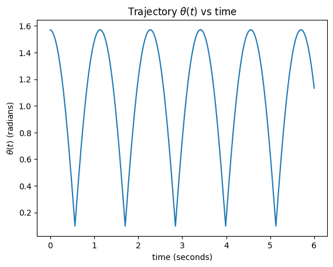

```python
# plot th(t)
plt.plot(tvec, x_traj[0,:])
plt.title(r'Trajectory $\theta(t)$ vs time')
plt.xlabel("time (seconds)")
plt.ylabel(r"$\theta(t)$ (radians)")
plt.show()
```

```python
animate_single_pend(x_traj[0,:], L=1, T=tf-t0)
```

[interactive chart not shown]

## Problem 5 (10pts)

```python
from IPython.core.display import HTML
display(HTML("<table><tr><td><img src='https://github.com/MuchenSun/ME314pngs/raw/master/tripend_constrained.JPG' width=500' height='450'></table>"))
```

We will now consider a constrained triple-pendulum system with the system configuration $q=[\theta_1, \theta_2, \theta_3]$. A constraint is such that *x coordinate* of the third pendulum (i.e. $m_3$) ONLY can not be smaller than 0 -- there exist a vertical wall high enough for third pendulum impact. Note that there is no constraint on *y coordinate* -- the top ceiling is infinitely high!

Similar to Problem 2, symbolically compute the following three expressions contained the equations above: $$\frac{\partial L}{\partial \dot{q}}, \quad \frac{\partial \phi}{\partial q}, \quad \frac{\partial L}{\partial \dot{q}}\cdot\dot{q} - L(q,\dot{q})$$

Use $m_1=m_2=m_3=1$ and $R_1=R_2=R_3=1$ as numerical values in the equations (i.e. **do not** define $m_1, m_2, m_3, R_1, R_2, R_3$ as symbols).

> Hint 1: As before, you will need to substitute $q$ and $\dot{q}$ with dummy symbols.

**Turn in: Include the code used to symbolically compute the three expressions, as well as code outputs - the resulting three expressions. Make sure there is no SymPy Function(t) left!**

```python
# Define the variables and parameters
t = sym.symbols(r't')

th1 = sym.Function(r'\theta1')(t)
th2 = sym.Function(r'\theta2')(t)
th3 = sym.Function(r'\theta3')(t)

th1_dot = th1.diff(t)
th2_dot = th2.diff(t)
th3_dot = th2.diff(t)

x1 = sym.sin(th1)
y1 = -sym.cos(th1)

x2 = x1 + sym.sin(th1 + th2)
y2 = y1 - sym.cos(th1 + th2)

x3 = x2 + sym.sin(th1 + th2 + th3)
y3 = y2 - sym.cos(th1 + th2 + th3)

x1_dot = x1.diff(t)
y1_dot = y1.diff(t)

x2_dot = x2.diff(t)
y2_dot = y2.diff(t)

x3_dot = x3.diff(t)
y3_dot = y3.diff(t)

KE1 = (x1_dot**2 + y1_dot**2)/2
PE1 = 9.8*y1

KE2 = (x2_dot**2 + y2_dot**2)/2
PE2 = 9.8*y2

KE3 = (x3_dot**2 + y3_dot**2)/2
PE3 = 9.8*y3

KE = KE1 + KE2 + KE3
PE = PE1 + PE2 + PE3

lagrangian = KE - PE
lagrangian = sym.simplify(lagrangian)

# Display Lagrangian
print('\033[1mLagrangian of the system: ')
display(lagrangian)
print("\n")

# Wrap the lagrangian into a SymPy Matrix
L = sym.Matrix([lagrangian])
# display(L)

q = sym.Matrix([th1, th2, th3])
qdot = q.diff(t)
qddot = qdot.diff(t)

# Compute Jacobian
dLdq = L.jacobian(q)
dLdqdot = L.jacobian(qdot)

# print('\033[1mEuler Lagrangian Equations')
EL = dLdqdot.diff(t) - dLdq

# LHS of the EL equations
lhs = sym.Matrix([exp for exp in EL])

# RHS of the EL equations
rhs = sym.Matrix([0 for exp in EL])

EL_eqns = sym.Eq(lhs, rhs)

solns = sym.solve(EL_eqns, qddot, dict=True)

# for sol_ in solns:
#     print('\n\033[1mSolution: ')
#     for q_ in qddot:
#         display(sym.simplify(sym.Eq(q_, sol_[q_])))
#         print("\n")


## Lamdifying the constant substituted solutions for theta1_ddot, theta2_ddot and theta3_ddot
# state_vec = [th1, qdot[0], th2, qdot[1], th3, qdot[2]]
# lambdified_solns = [sym.lambdify(state_vec, soln_[qddot_], modules='numpy') for soln_ in solns for qddot_ in qddot]
# th1ddot_func, th2ddot_func, th3ddot_func = lambdified_solns
```

```
Lagrangian of the system:
```

$\displaystyle 19.6 \cos{\left(\theta1{\left(t \right)} + \theta2{\left(t \right)} \right)} + 1.0 \cos{\left(\theta2{\left(t \right)} + \theta3{\left(t \right)} \right)} \left(\frac{d}{d t} \theta1{\left(t \right)}\right)^{2} + 1.0 \cos{\left(\theta2{\left(t \right)} + \theta3{\left(t \right)} \right)} \frac{d}{d t} \theta1{\left(t \right)} \frac{d}{d t} \theta2{\left(t \right)} + 1.0 \cos{\left(\theta2{\left(t \right)} + \theta3{\left(t \right)} \right)} \frac{d}{d t} \theta1{\left(t \right)} \frac{d}{d t} \theta3{\left(t \right)} + 9.8 \cos{\left(\theta1{\left(t \right)} + \theta2{\left(t \right)} + \theta3{\left(t \right)} \right)} + 29.4 \cos{\left(\theta1{\left(t \right)} \right)} + 2.0 \cos{\left(\theta2{\left(t \right)} \right)} \left(\frac{d}{d t} \theta1{\left(t \right)}\right)^{2} + 2.0 \cos{\left(\theta2{\left(t \right)} \right)} \frac{d}{d t} \theta1{\left(t \right)} \frac{d}{d t} \theta2{\left(t \right)} + 1.0 \cos{\left(\theta3{\left(t \right)} \right)} \left(\frac{d}{d t} \theta1{\left(t \right)}\right)^{2} + 2.0 \cos{\left(\theta3{\left(t \right)} \right)} \frac{d}{d t} \theta1{\left(t \right)} \frac{d}{d t} \theta2{\left(t \right)} + 1.0 \cos{\left(\theta3{\left(t \right)} \right)} \frac{d}{d t} \theta1{\left(t \right)} \frac{d}{d t} \theta3{\left(t \right)} + 1.0 \cos{\left(\theta3{\left(t \right)} \right)} \left(\frac{d}{d t} \theta2{\left(t \right)}\right)^{2} + 1.0 \cos{\left(\theta3{\left(t \right)} \right)} \frac{d}{d t} \theta2{\left(t \right)} \frac{d}{d t} \theta3{\left(t \right)} + 3.0 \left(\frac{d}{d t} \theta1{\left(t \right)}\right)^{2} + 3.0 \frac{d}{d t} \theta1{\left(t \right)} \frac{d}{d t} \theta2{\left(t \right)} + 1.0 \frac{d}{d t} \theta1{\left(t \right)} \frac{d}{d t} \theta3{\left(t \right)} + 1.5 \left(\frac{d}{d t} \theta2{\left(t \right)}\right)^{2} + 1.0 \frac{d}{d t} \theta2{\left(t \right)} \frac{d}{d t} \theta3{\left(t \right)} + 0.5 \left(\frac{d}{d t} \theta3{\left(t \right)}\right)^{2}$

```python
def th1ddot_func(theta1_k, theta1_dot_k, theta2_k, theta2_dot_k, theta3_k, theta3_dot_k):
  subs_ = {
    q[0]:theta1_k,
    q[1]:theta2_k,
    q[2]:theta3_k,
    qdot[0]:theta1_dot_k,
    qdot[1]:theta2_dot_k,
    qdot[2]:theta3_dot_k
    }

  return sym.N(solns[0][qddot[0]].subs(subs_))


def th2ddot_func(theta1_k, theta1_dot_k, theta2_k, theta2_dot_k, theta3_k, theta3_dot_k):
  subs_ = {
    q[0]:theta1_k,
    q[1]:theta2_k,
    q[2]:theta3_k,
    qdot[0]:theta1_dot_k,
    qdot[1]:theta2_dot_k,
    qdot[2]:theta3_dot_k
    }

  return sym.N(solns[0][qddot[1]].subs(subs_))

def th3ddot_func(theta1_k, theta1_dot_k, theta2_k, theta2_dot_k, theta3_k, theta3_dot_k):
  subs_ = {
    q[0]:theta1_k,
    q[1]:theta2_k,
    q[2]:theta3_k,
    qdot[0]:theta1_dot_k,
    qdot[1]:theta2_dot_k,
    qdot[2]:theta3_dot_k
    }

  return sym.N(solns[0][qddot[2]].subs(subs_))
```

```python
# Define the phi(q)
phi = x3 - 0
print("Phi")
display(phi)
print("\n")

dPhidq = sym.simplify(sym.Matrix([phi]).jacobian(q).T)
print("Gradient of the surface along q:")
display(dPhidq)
print("\n")

# Compute dL/dqdot
print("dL/dqdot")
display(dLdqdot)
print("\n")

# Define the hamiltonian
hamiltonian = sym.simplify(dLdqdot.T.dot(qdot)-lagrangian)
print("Hamiltonian:")
display(hamiltonian)
```

```
Phi
```

$\displaystyle \sin{\left(\theta1{\left(t \right)} + \theta2{\left(t \right)} \right)} + \sin{\left(\theta1{\left(t \right)} + \theta2{\left(t \right)} + \theta3{\left(t \right)} \right)} + \sin{\left(\theta1{\left(t \right)} \right)}$

```
Gradient of the surface along q:
```

$\displaystyle \left[\begin{matrix}\cos{\left(\theta1{\left(t \right)} + \theta2{\left(t \right)} \right)} + \cos{\left(\theta1{\left(t \right)} + \theta2{\left(t \right)} + \theta3{\left(t \right)} \right)} + \cos{\left(\theta1{\left(t \right)} \right)}\\\cos{\left(\theta1{\left(t \right)} + \theta2{\left(t \right)} \right)} + \cos{\left(\theta1{\left(t \right)} + \theta2{\left(t \right)} + \theta3{\left(t \right)} \right)}\\\cos{\left(\theta1{\left(t \right)} + \theta2{\left(t \right)} + \theta3{\left(t \right)} \right)}\end{matrix}\right]$

```
dL/dqdot
```

$\displaystyle \left[\begin{matrix}2.0 \cos{\left(\theta2{\left(t \right)} + \theta3{\left(t \right)} \right)} \frac{d}{d t} \theta1{\left(t \right)} + 1.0 \cos{\left(\theta2{\left(t \right)} + \theta3{\left(t \right)} \right)} \frac{d}{d t} \theta2{\left(t \right)} + 1.0 \cos{\left(\theta2{\left(t \right)} + \theta3{\left(t \right)} \right)} \frac{d}{d t} \theta3{\left(t \right)} + 4.0 \cos{\left(\theta2{\left(t \right)} \right)} \frac{d}{d t} \theta1{\left(t \right)} + 2.0 \cos{\left(\theta2{\left(t \right)} \right)} \frac{d}{d t} \theta2{\left(t \right)} + 2.0 \cos{\left(\theta3{\left(t \right)} \right)} \frac{d}{d t} \theta1{\left(t \right)} + 2.0 \cos{\left(\theta3{\left(t \right)} \right)} \frac{d}{d t} \theta2{\left(t \right)} + 1.0 \cos{\left(\theta3{\left(t \right)} \right)} \frac{d}{d t} \theta3{\left(t \right)} + 6.0 \frac{d}{d t} \theta1{\left(t \right)} + 3.0 \frac{d}{d t} \theta2{\left(t \right)} + 1.0 \frac{d}{d t} \theta3{\left(t \right)} & 1.0 \cos{\left(\theta2{\left(t \right)} + \theta3{\left(t \right)} \right)} \frac{d}{d t} \theta1{\left(t \right)} + 2.0 \cos{\left(\theta2{\left(t \right)} \right)} \frac{d}{d t} \theta1{\left(t \right)} + 2.0 \cos{\left(\theta3{\left(t \right)} \right)} \frac{d}{d t} \theta1{\left(t \right)} + 2.0 \cos{\left(\theta3{\left(t \right)} \right)} \frac{d}{d t} \theta2{\left(t \right)} + 1.0 \cos{\left(\theta3{\left(t \right)} \right)} \frac{d}{d t} \theta3{\left(t \right)} + 3.0 \frac{d}{d t} \theta1{\left(t \right)} + 3.0 \frac{d}{d t} \theta2{\left(t \right)} + 1.0 \frac{d}{d t} \theta3{\left(t \right)} & 1.0 \cos{\left(\theta2{\left(t \right)} + \theta3{\left(t \right)} \right)} \frac{d}{d t} \theta1{\left(t \right)} + 1.0 \cos{\left(\theta3{\left(t \right)} \right)} \frac{d}{d t} \theta1{\left(t \right)} + 1.0 \cos{\left(\theta3{\left(t \right)} \right)} \frac{d}{d t} \theta2{\left(t \right)} + 1.0 \frac{d}{d t} \theta1{\left(t \right)} + 1.0 \frac{d}{d t} \theta2{\left(t \right)} + 1.0 \frac{d}{d t} \theta3{\left(t \right)}\end{matrix}\right]$

```
Hamiltonian:
```

$\displaystyle - 19.6 \cos{\left(\theta1{\left(t \right)} + \theta2{\left(t \right)} \right)} + 1.0 \cos{\left(\theta2{\left(t \right)} + \theta3{\left(t \right)} \right)} \left(\frac{d}{d t} \theta1{\left(t \right)}\right)^{2} + 1.0 \cos{\left(\theta2{\left(t \right)} + \theta3{\left(t \right)} \right)} \frac{d}{d t} \theta1{\left(t \right)} \frac{d}{d t} \theta2{\left(t \right)} + 1.0 \cos{\left(\theta2{\left(t \right)} + \theta3{\left(t \right)} \right)} \frac{d}{d t} \theta1{\left(t \right)} \frac{d}{d t} \theta3{\left(t \right)} - 9.8 \cos{\left(\theta1{\left(t \right)} + \theta2{\left(t \right)} + \theta3{\left(t \right)} \right)} - 29.4 \cos{\left(\theta1{\left(t \right)} \right)} + 2.0 \cos{\left(\theta2{\left(t \right)} \right)} \left(\frac{d}{d t} \theta1{\left(t \right)}\right)^{2} + 2.0 \cos{\left(\theta2{\left(t \right)} \right)} \frac{d}{d t} \theta1{\left(t \right)} \frac{d}{d t} \theta2{\left(t \right)} + 1.0 \cos{\left(\theta3{\left(t \right)} \right)} \left(\frac{d}{d t} \theta1{\left(t \right)}\right)^{2} + 2.0 \cos{\left(\theta3{\left(t \right)} \right)} \frac{d}{d t} \theta1{\left(t \right)} \frac{d}{d t} \theta2{\left(t \right)} + 1.0 \cos{\left(\theta3{\left(t \right)} \right)} \frac{d}{d t} \theta1{\left(t \right)} \frac{d}{d t} \theta3{\left(t \right)} + 1.0 \cos{\left(\theta3{\left(t \right)} \right)} \left(\frac{d}{d t} \theta2{\left(t \right)}\right)^{2} + 1.0 \cos{\left(\theta3{\left(t \right)} \right)} \frac{d}{d t} \theta2{\left(t \right)} \frac{d}{d t} \theta3{\left(t \right)} + 3.0 \left(\frac{d}{d t} \theta1{\left(t \right)}\right)^{2} + 3.0 \frac{d}{d t} \theta1{\left(t \right)} \frac{d}{d t} \theta2{\left(t \right)} + 1.0 \frac{d}{d t} \theta1{\left(t \right)} \frac{d}{d t} \theta3{\left(t \right)} + 1.5 \left(\frac{d}{d t} \theta2{\left(t \right)}\right)^{2} + 1.0 \frac{d}{d t} \theta2{\left(t \right)} \frac{d}{d t} \theta3{\left(t \right)} + 0.5 \left(\frac{d}{d t} \theta3{\left(t \right)}\right)^{2}$

```python
hamiltonain_func = sym.lambdify([th1, qdot[0], th2, qdot[1], th3, qdot[2]], hamiltonian)
```

## Problem 6 (10pts)

Similar to Problem 3, now you need to define dummy symbols for $\dot{q}(\tau^+)$, define the equations for impact update rules. Note that you don't need to solve the equations in this problem - in fact it's very time consuming to solve the analytical solution, and we will use a trick to get around it later!

**Turn in: Include a copy of the code used to define the equations for impact update and the code output (i.e. print out of the equations).**

```python
lambda_ = sym.symbols(r'\lambda')

th1_minus, th1dot_minus, th2_minus, th2dot_minus, th3_minus, th3dot_minus = \
sym.symbols(r'\theta1^-, \dot{\theta1}^-, \theta2^-, \dot{\theta2}^-, \theta3^-, \dot{\theta3}^-')

th1dot_plus, th2dot_plus, th3dot_plus = sym.symbols(r'\dot{\theta1}^+, \dot{\theta2}^+, \dot{\theta3}^+')


subs_minus = {
    q[0]:th1_minus,
    q[1]:th2_minus,
    q[2]:th3_minus,
    qdot[0]:th1dot_minus,
    qdot[1]:th2dot_minus,
    qdot[2]:th3dot_minus
    }

subs_plus = {
    q[0]:th1_minus,
    q[1]:th2_minus,
    q[2]:th3_minus,
    qdot[0]:th1dot_plus,
    qdot[1]:th2dot_plus,
    qdot[2]:th3dot_plus
    }

# display(qdot_plus)

# Momentum before and after impact
dLdqdot_minus = dLdqdot.subs(subs_minus)
dLdqdot_plus = dLdqdot.subs(subs_plus)

# Compute dPhidq and evaluate it at tau-
dPhidq_minus = dPhidq.subs(subs_minus)

# Compute hamiltonian at tau- and tau+
hamiltonian_minus = hamiltonian.subs(subs_minus)
hamiltonian_plus = hamiltonian.subs(subs_plus)


impact_eqns_lhs = sym.Matrix([ dLdqdot_plus[0] - dLdqdot_minus[0], dLdqdot_plus[1] - dLdqdot_minus[1], dLdqdot_plus[2] - dLdqdot_minus[2], hamiltonian_plus - hamiltonian_minus ])
impact_eqns_rhs = sym.Matrix([ lambda_ * dPhidq_minus[0], lambda_ * dPhidq_minus[1], lambda_ * dPhidq_minus[2], 0 ])
impact_eqns = sym.Eq(impact_eqns_lhs, impact_eqns_rhs)
print('Equations for impact update:')
display(impact_eqns)
```

[output not shown]

```
Equations for impact update:
```

## Problem 7 (15pts)

Since solving the analytical symbolic solution of the impact update rules for the triple-pendulum system is too slow, here we will solve it along within the simulation. The idea is, when the impact happens, substitute the numerical values of $q$ and $\dot{q}$ at that moment into the equations you got in Problem 6, thus you will just need to solve a set equations with most terms being numerical values (which is very fast).

**Turn in: A copy of your "impact_update_triple_pend" function, and the test result of your function.**

```python
def impact_update_triple_pend(x):

  subs_values = {
      th1_minus:x[0],
      th2_minus:x[2],
      th3_minus:x[4],
      th1dot_minus:x[1],
      th2dot_minus:x[3],
      th3dot_minus:x[5]
  }


  impact_equations_subs = impact_eqns.subs(subs_values)
  # display(impact_equations_subs)
  # print("In impact_update_triple_pend")

  impact_solns = sym.solve(impact_equations_subs, [th1dot_plus, th2dot_plus, th3dot_plus, lambda_])
  # print(impact_solns)

  if(len(impact_solns) > 1):
    if(abs(impact_solns[0][3]) < 1e-2):
      # print("1")
      # print(np.array([x[0], impact_solns[1][0], x[2], impact_solns[1][1], x[4], impact_solns[1][2]]))
      return np.array([x[0], impact_solns[1][0], x[2], impact_solns[1][1], x[4], impact_solns[1][2]])
    else:
      # print("2")
      # print(np.array([x[0], impact_solns[0][0], x[2], impact_solns[0][1], x[4], impact_solns[0][2]]))
      return np.array([x[0], impact_solns[0][0], x[2], impact_solns[0][1], x[4], impact_solns[0][2]])
  else:
      # print("3")
      # print(np.array([x[0], impact_solns[0][0], x[2], impact_solns[0][1], x[4], impact_solns[0][2]]))
      return np.array([x[0], impact_solns[0][0], x[2], impact_solns[0][1], x[4], impact_solns[0][2]])

print("Test for the impact_update_triple_pend for the given input {}".format(impact_update_triple_pend([0, 1, 0, 1, 0, 1])))
```

```
Test for the impact_update_triple_pend for the given input [0 1.00000000000000 0 1.00000000000000 0 -11.0000000000000]
```

## Problem 8 (15pts)

Similar to the single-pendulum system, you will still want to implement a function named "impact_condition_triple_pend" to indicate the moment when impact happens. Again, you need to use the constraint $\phi$. After obtaining the impact condition function, simulate the triple-pendulum system with impact for $t\in[0,2], dt=0.01$ with initial condition $\theta_1=\frac{\pi}{3}, \theta_2=\frac{\pi}{3}, \theta_3=-\frac{\pi}{3}$ and $\dot{\theta}_1=\dot{\theta}_2=\dot{\theta}_3=0$. Plot the simulated trajectory versus time and animate your simulated trajectory.

> Hint 1: You will need to modify the simulate function!

**Turn in: A copy of code for the impact update function and simulate function, as well as code output including the plot of simulated trajectory and the animation. The video should be uploaded separately from the .pdf file through Canvas, and it should be in ".mp4" format. You can use screen capture or record the screen directly with your phone.**

```python
phi_func = sym.lambdify([th1, th1_dot, th2, th2_dot, th3, th3_dot], phi)

def impact_condition_triple_pend(x, threshold=1e-1):
  th1 = x[0]
  th2 = x[2]
  th3 = x[4]
  th1_dot = x[1]
  th2_dot = x[3]
  th3_dot = x[5]
  phi_eval = phi_func(th1, th1_dot, th2, th2_dot, th3, th3_dot)

  if(abs(phi_eval) < threshold):
    return True

  return False

# define extended dynamics for the triple pendulum system
def triple_pendulum_dyn(x):
  """
    System dynamics function (extended)

    Parameters
    ============
    x: NumPy array
    x = [th1, th2, th3, th1dot th2dot, th3dot] is the extended system
    state vector, includng the position and
    the velocity of the particle

    Return
    ============
    xdot: NumPy array
    time derivative of input state vector,
    xdot = [th1dot th2dot, th3dot, th1ddot, th2ddot, th3ddot]

  """
  theta1_k = x[0]
  theta2_k = x[2]
  theta3_k = x[4]
  theta1_dot_k = x[1]
  theta2_dot_k = x[3]
  theta3_dot_k = x[5]

  theta1_ddot_k = th1ddot_func(theta1_k, theta1_dot_k, theta2_k, theta2_dot_k, theta3_k, theta3_dot_k)
  theta2_ddot_k = th2ddot_func(theta1_k, theta1_dot_k, theta2_k, theta2_dot_k, theta3_k, theta3_dot_k)
  theta3_ddot_k = th3ddot_func(theta1_k, theta1_dot_k, theta2_k, theta2_dot_k, theta3_k, theta3_dot_k)

  return np.array([theta1_dot_k, theta1_ddot_k, theta2_dot_k, theta2_ddot_k, theta3_dot_k, theta3_ddot_k])

# define simulate function
def simulate_triple_pend_with_impact(f, x0, tspan, dt, integrate):

    N = int((max(tspan) - min(tspan)) / dt)
    x = np.copy(x0)
    tvec = np.linspace(min(tspan), max(tspan), N)
    xtraj = np.zeros((len(x0), N))
    impact_eval = False
    for i in range(N):
        if impact_condition_triple_pend(x) is True and not impact_eval:
            x = impact_update_triple_pend(x)
            xtraj[:, i] = integrate(f, x, dt)
            impact_eval = True
        else:
            xtraj[:, i] = integrate(f, x, dt)
            impact_eval = False
        x = np.copy(xtraj[:, i])

    return xtraj

# Simulation parameters
t0 = 0
tf = 2.0
dt = 0.01
N = int((tf - t0)/dt)
tvec = np.linspace(t0, tf, N)

# initial conditions
x0 = np.array([np.pi/3, 0, np.pi/3, 0, -np.pi/3, 0])
# simulate the trajectory
x_traj = simulate_triple_pend_with_impact(triple_pendulum_dyn, x0, tspan=[t0, tf], dt=dt, integrate=integrate)
```

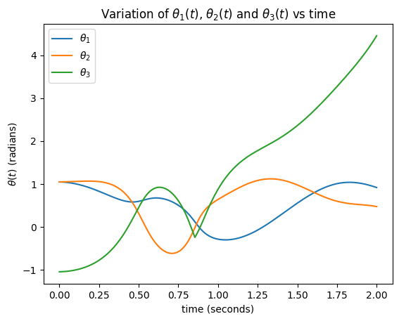

```python
# plot
plt.plot(tvec, x_traj[0,:], label=r"$\theta_1$")
plt.plot(tvec, x_traj[2,:], label=r"$\theta_2$")
plt.plot(tvec, x_traj[4,:], label=r"$\theta_3$")
plt.title(r'Variation of $\theta_1(t)$, $\theta_2(t)$ and $\theta_3(t)$ vs time')
plt.xlabel("time (seconds)")
plt.ylabel(r"$\theta(t)$ (radians)")
plt.legend()
plt.show()
```

```python
animate_triple_pend(np.delete(x_traj, [1,3,5], axis=0), L1=1, L2=1, L3=1, T=tf-t0)
```

[interactive chart not shown]

## Problem 9 (5pts)

Compute and plot the Hamiltonian of the simulated trajectory for the triple-pendulum system with impact.

**Turn in: A copy of code used to compute the Hamiltonian, also include the code output, which should the plot of the Hamiltonian versus time.**

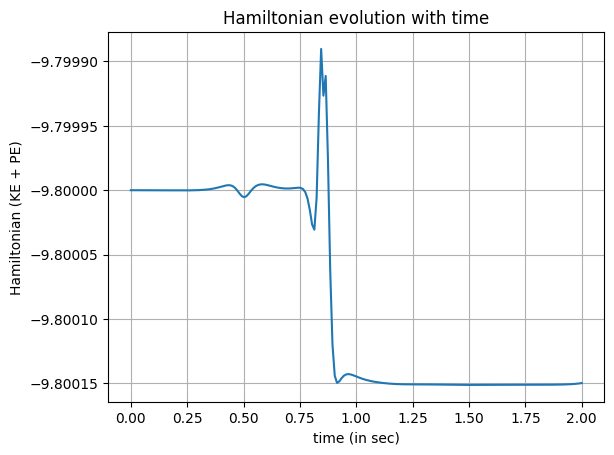

```python
def compute_hamiltonian_traj(x_traj):

  hamiltonian_traj = []
  for col in range(x_traj.shape[1]):
    th1_k, th1_dot_k, th2_k, th2_dot_k, th3, th3_dot_k = x_traj[:, col]
    # print(x_traj[:, col])
    h_k = hamiltonain_func(th1_k, th1_dot_k, th2_k, th2_dot_k, th3, th3_dot_k)
    hamiltonian_traj.append(h_k)

  return np.array(hamiltonian_traj)

hamiltonian_traj = compute_hamiltonian_traj(x_traj)

# Set title and labels
plt.title(r"Hamiltonian evolution with time")
plt.xlabel("time (in sec)")
plt.ylabel("Hamiltonian (KE + PE)")
plt.grid(True)
plt.ticklabel_format(style='plain', axis='y', useOffset=False)

plt.plot(tvec, hamiltonian_traj[:])
```